# hw06-donghan2

Liu, Donghan, Donghan2

03/16/2018

```r
# general
library(MASS)
library(caret)
library(tidyverse)
library(knitr)
library(kableExtra)
library(mlbench)

# specific
library(randomForest)
library(gbm)
library(klaR)
library(ellipse)
```

```r
data(Boston, package = "MASS")
set.seed(1)
bstn_idx = createDataPartition(Boston$medv, p = 0.75, list = FALSE)
bstn_trn = Boston[bstn_idx, ]
bstn_tst = Boston[-bstn_idx, ]
```

## Exercise 1 (Tuning KNN Regression with caret)

```r
calc_rmse = function(actual, predicted) {
  sqrt(mean((actual - predicted) ^ 2))
}
```

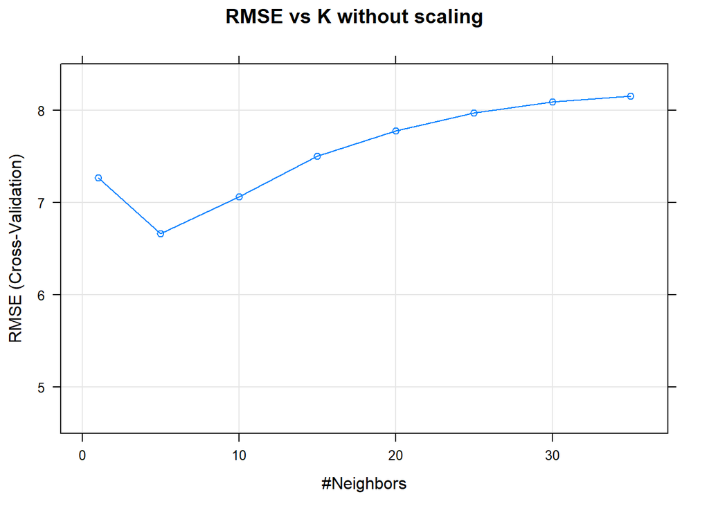

```r
set.seed(1337)
k = c(1,5,10,15,20,25,30,35)
knn1 = train(form = medv ~ .,
              data = bstn_trn,
              trControl = trainControl(method = 'cv', number = 5),
              method = 'knn',
              tuneGrid = expand.grid(k = k))
knn2 = train(form = medv ~ .,
              data = bstn_trn,
              trControl = trainControl(method = 'cv', number = 5),
              method = 'knn',
              tuneGrid = expand.grid(k = k),
              preProcess = 'scale')
par(mfrow = c(1,2))
plot(knn1,ylim = c(4.5,8.5),main = "RMSE vs K without scaling")
```

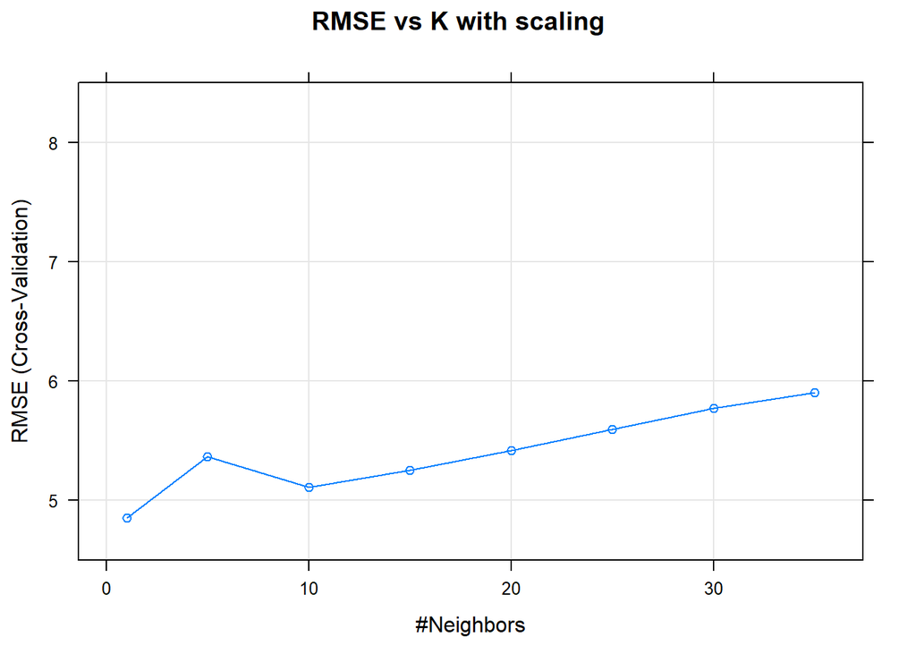

```r
plot(knn2,ylim = c(4.5,8.5),main = "RMSE vs K with scaling")
```

## Exercise 2 (More Regression with caret)

```r
gbm_grid = expand.grid(interaction.depth = c(1, 2, 3),
                       n.trees = (1:20) * 100,
                       shrinkage = c(0.1, 0.3),
                       n.minobsinnode = 20)
```

```r
set.seed(1337)
add = train(form = medv ~ .,
              data = bstn_trn,
              trControl = trainControl(method = 'cv', number = 5),
              method = 'glm')

rf = train(form = medv ~ .,
              data = bstn_trn,
              trControl = trainControl(method = 'cv', number = 5),
              method = 'rf')

gbm = train(form = medv ~ .,
              data = bstn_trn,
              trControl = trainControl(method = 'cv', number = 5),
              method = 'gbm',
              tuneGrid = gbm_grid)
```

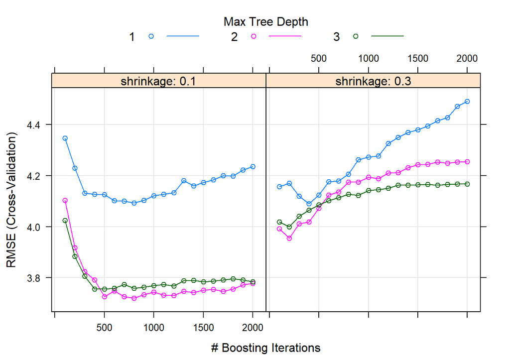

```r
plot(gbm)
```

```r
get_best_result = function(caret_fit) {
  best = which(rownames(caret_fit$results) == rownames(caret_fit$bestTune))
  best_result = caret_fit$results[best, ]
  rownames(best_result) = NULL
  best_result
}
```

```r
rmse1 = calc_rmse(bstn_tst$medv, predict(add,bstn_tst))
rmse2 = calc_rmse(bstn_tst$medv, predict(rf,bstn_tst))
rmse3 = calc_rmse(bstn_tst$medv, predict(gbm,bstn_tst))
rmse4 = calc_rmse(bstn_tst$medv, predict(knn1,bstn_tst))
rmse5 = calc_rmse(bstn_tst$medv, predict(knn2,bstn_tst))


best_rmse1 = get_best_result(add)$RMSE
best_rmse2 = get_best_result(rf)$RMSE
best_rmse3 = get_best_result(gbm)$RMSE
best_rmse4 = get_best_result(knn1)$RMSE
best_rmse5 = get_best_result(knn2)$RMSE

results = data.frame(Model = c("Additive","Random Forest","Boosted Tree", "KNN without Scalling", "KNN with Scalling"),Cross_Validation_RMSE = c(best_rmse1,best_rmse2,best_rmse3,best_rmse4,best_rmse5), RMSE = c(rmse1,rmse2,rmse3,rmse4,rmse5))

kable_styling(kable(results, format = "html", digits = 3), full_width = FALSE)
```

| Model | Cross_Validation_RMSE | RMSE |
| --- | --- | --- |
| Additive | 4.922 | 4.608 |
| Random Forest | 3.336 | 3.617 |
| Boosted Tree | 3.721 | 3.557 |
| KNN without Scalling | 6.660 | 6.014 |
| KNN with Scalling | 4.855 | 4.347 |

## Exercise 3 (Clasification with caret)

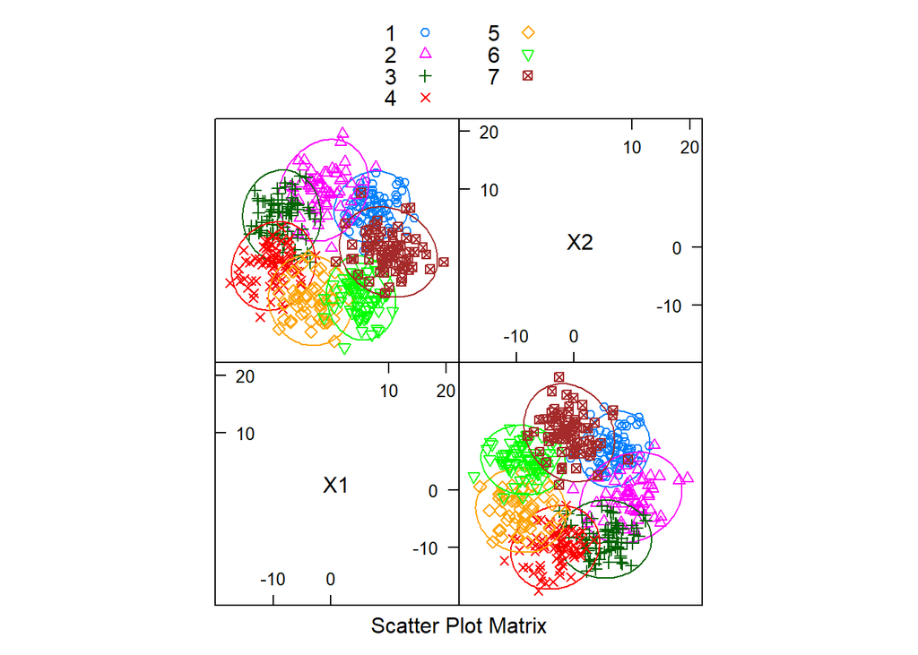

```r
set.seed(42)
# simulate data using mlbench
sim_trn = mlbench.2dnormals(n = 500, cl = 7, r = 10, sd = 3)
# create tidy data
sim_trn = data.frame(
  classes = sim_trn$classes,
  sim_trn$x
)
featurePlot(x = sim_trn[, -1],
            y = sim_trn$classes,
            plot = "ellipse",
            auto.key = list(columns = 2),
            par.settings = list(superpose.symbol = list(pch = 1:9))
)
```

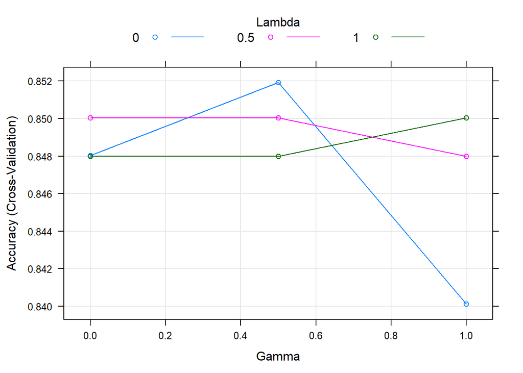

```r
set.seed(1337)

lda = train(form = classes ~ .,data = sim_trn,
            trControl = trainControl(method = 'cv', number = 10),
            method = 'lda')

qda = train(form = classes ~ .,data = sim_trn,
            trControl = trainControl(method = 'cv', number = 10),
            method = 'qda')

nb = train(form = classes ~ .,data = sim_trn,
            trControl = trainControl(method = 'cv', number = 10),
            method = 'nb')

rda = train(form = classes ~ .,data = sim_trn,
            trControl = trainControl(method = 'cv', number = 10),
            method = 'rda')

grid = expand.grid(mtry = c(1,2))
rf = train(form = classes ~ .,data = sim_trn,
            trControl = trainControl(method = 'cv', number = 10),
            method = 'rf',
           tuneGrid = grid)

plot(rda)
```

```r
results = data.frame(Model = c("LDA","QDA","Naive Bayes","RDA","Random Forest"), Accuracy = c(get_best_result(lda)$Accuracy
,get_best_result(qda)$Accuracy
,get_best_result(nb)$Accuracy
,get_best_result(rda)$Accuracy
,get_best_result(rf)$Accuracy
), AccuracySD = c(get_best_result(lda)$AccuracySD
,get_best_result(qda)$AccuracySD
,get_best_result(nb)$AccuracySD
,get_best_result(rda)$AccuracySD
,get_best_result(rf)$AccuracySD
))
kable_styling(kable(results, format = "html", digits = 4), full_width = FALSE)
```

| Model | Accuracy | AccuracySD |
| --- | --- | --- |
| LDA | 0.8514 | 0.0491 |
| QDA | 0.8499 | 0.0436 |
| Naive Bayes | 0.8568 | 0.0696 |
| RDA | 0.8519 | 0.0344 |
| Random Forest | 0.8180 | 0.0405 |

## Exercise 4

### Regression

**(a)**

From the RMSE plot, I would choose k = 5 for KNN without predictor scaling

**(b)**

The plot shows when k = 1, the RMSE is lowest with predictor scaling

**(c)**

```r
gbm$bestTune
```

```
##    n.trees interaction.depth shrinkage n.minobsinnode
## 28     800                 2       0.1             20
```

From the above table, the number of trees is 800, interaction.depth is 2, shrinkage is 0.1, and number of minobsinnode is 20

**(d)**

The model of random forest has the lowest cross-validation RMSE value, which is 3.336

**(e)**

The boosted tree model has the lowest test error, which is 3.557

### Classification

**(f)**

```r
rda$bestTune
```

```
##   gamma lambda
## 4   0.5      0
```

From the above table, the tuning parameters with gamma of 0.5 and lambda = 0 are chosen for RDA model

**(g)**

I believe QDA is more appropriate here because the ellipse plot shows that they has the different shape and different loacation

**(h)**

I believe QDA is more appropriate than Naive Bayes since they are not completely seperated and there is some overlaps, so QDA seems appropriate here.

**(i)**

The model of Naive Bayes has the hightest (best) cross-validated accuracy

**(j)**

I do not believe so because accuracy standard deviation of Naive Bayes is the highest one. However, RDA could be chose instead since it has the lowest standard deviation and relatively high accuracy.